**MIT License (click to expand)**

```
MIT License
Copyright (c) 2023-2026 AI Course Notebook Contributors
Repository: https://github.com/arch-inform-kaken-group/ai-course-notebooks

Permission is hereby granted, free of charge, to any person obtaining a copy
of this software and associated documentation files (the "Software"), to deal
in the Software without restriction, including without limitation the rights
to use, copy, modify, merge, publish, distribute, sublicense, and/or sell
copies of the Software, and to permit persons to whom the Software is
furnished to do so, subject to the following conditions:

The above copyright notice and this permission notice shall be included in all
copies or substantial portions of the Software.

THE SOFTWARE IS PROVIDED "AS IS", WITHOUT WARRANTY OF ANY KIND, EXPRESS OR
IMPLIED, INCLUDING BUT NOT LIMITED TO THE WARRANTIES OF MERCHANTABILITY,
FITNESS FOR A PARTICULAR PURPOSE AND NONINFRINGEMENT. IN NO EVENT SHALL THE
AUTHORS OR COPYRIGHT HOLDERS BE LIABLE FOR ANY CLAIM, DAMAGES OR OTHER
LIABILITY, WHETHER IN AN ACTION OF CONTRACT, TORT OR OTHERWISE, ARISING FROM,
OUT OF OR IN CONNECTION WITH THE SOFTWARE OR THE USE OR OTHER DEALINGS IN THE
SOFTWARE.
```

# Fashion MNIST （服飾商品画像）の教師あり分類

今回のハンズオンは，深層学習モデルの1つである，畳み込みニューラルネットワーク（Convolutional Neural Network；CNN）を作成する流れのイメージを体感していただくことが目標です．

## 目的：10種類の服飾商品の画像を分類すること

Fashion MNIST （服飾商品画像）は，10種類の服飾商品による画像データセットであり，機械学習・深層学習分野における練習問題などで，しばしば使用されるデータセットです． これも，幾つかのPythonのライブラリではお試し用のデータとして簡単に使用できるようになっています．

Fashion-MNIST データセットの【正解ラベル，クラス名，サンプル画像】の対応表：

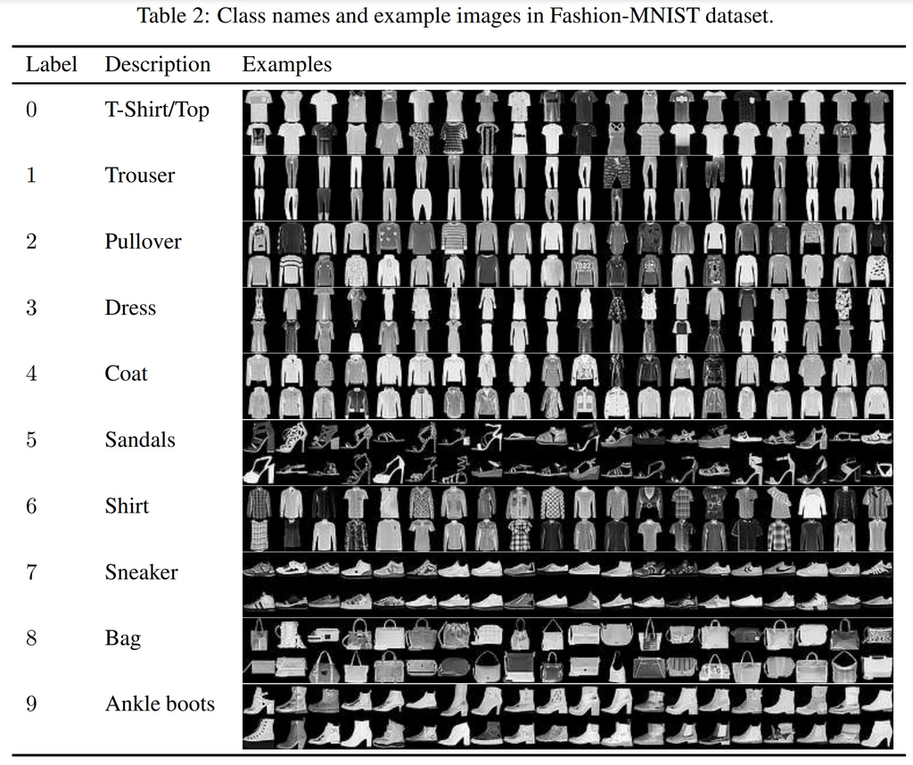

Fashion-MNIST: a Novel Image Dataset for Benchmarking Machine Learning Algorithms. (May. 8, 2023, 00:30 UTC). In arXiv:The Open Access Eprint Archive. Retrieved from https://arxiv.org/pdf/1708.07747

| ラベル「0」： T-shirt/top（Tシャツ/トップス） |
| --- |
| ラベル「1」： Trouser（ズボン） |
| ラベル「2」： Pullover（プルオーバー，頭から被って着る服） |
| ラベル「3」： Dress（ドレス） |
| ラベル「4」： Coat（コート） |
| ラベル「5」： Sandal（サンダル） |
| ラベル「6」： Shirt（シャツ） |
| ラベル「7」： Sneaker（スニーカー） |
| ラベル「8」： Bag（バッグ） |
| ラベル「9」： Ankle boot（アンクルブーツ，かかとが隠れる丈のブーツ） |

今回は，服飾商品の種別毎に，ラベル「0」～「9」が割り当てられている服飾商品の画像を，深層学習モデルを用いてラベル「0」～「9」に自動で分類を行います．

使える情報（入力データの種類）：10種類の服飾商品画像  
取得したい結果（出力データの種類）：服飾商品の種別毎に割り当てられた「0」～「9」の数値ラベル

手書き数字のMNISTデータセットと同様に，Fashion-MNISTでも下記のような一通りの前処理が行われているため，手軽に実データを使用することが出来ます．

- 画像中の服飾商品の大きさが揃えられている．
- 服飾商品画像は画像の中央に配置されている．
- 訓練用とテスト用にデータセットが分割されている（学習用：60000件，テスト用：10000件）．
- 正解ラベルが割り当てられている．

Fashion-MNIST データセット出典：  
［本家（arXiv）］[Han Xiao and Kashif Rasul and Roland Vollgraf. Fashion-MNIST: a Novel Image Dataset for Benchmarking Machine Learning Algorithms. 15 Sep 2017, arXiv:1708.07747](https://arxiv.org/abs/1708.07747)

［本家（GitHub）］https://github.com/zalandoresearch/fashion-mnist

## GPU の利用確認とTensorFlowのバージョン確認

```python
!nvidia-smi
```

```
Wed May 13 02:25:14 2026
+-----------------------------------------------------------------------------------------+
| NVIDIA-SMI 580.82.07              Driver Version: 580.82.07      CUDA Version: 13.0     |
+-----------------------------------------+------------------------+----------------------+
| GPU  Name                 Persistence-M | Bus-Id          Disp.A | Volatile Uncorr. ECC |
| Fan  Temp   Perf          Pwr:Usage/Cap |           Memory-Usage | GPU-Util  Compute M. |
|                                         |                        |               MIG M. |
|=========================================+========================+======================|
|   0  Tesla T4                       Off |   00000000:00:04.0 Off |                    0 |
| N/A   35C    P8             10W /   70W |       0MiB /  15360MiB |      0%      Default |
|                                         |                        |                  N/A |
+-----------------------------------------+------------------------+----------------------+

+-----------------------------------------------------------------------------------------+
| Processes:                                                                              |
|  GPU   GI   CI              PID   Type   Process name                        GPU Memory |
|        ID   ID                                                               Usage      |
|=========================================================================================|
|  No running processes found                                                             |
+-----------------------------------------------------------------------------------------+
```

```python
import tensorflow as tf
import sklearn
import os


# colab にプリインストールされていないライブラリを導入
!pip install -q japanize_matplotlib # matplotlib日本語化用の外部ライブラリ

print('TensorFlow version:',tf.__version__)
print('scikit-learn version:',sklearn.__version__)

restart_flag = False

if tf.__version__ != '2.20.0':
    !pip install -q --upgrade tensorflow==2.20.0
    print('TensorFlow version:',tf.__version__)
    restart_flag = True

if sklearn.__version__ != '1.6.1':
    !pip install -q --upgrade scikit-learn==1.6.1
    print('scikit-learn version:',sklearn.__version__)
    restart_flag = True

# 以下は，ライブラリのバージョンが変更された場合のみ実行されます．
if restart_flag :
    print("ライブラリバージョンを変更した場合に，自動でランタイムを再起動します．")
    print("colabの場合は【不明な理由でクラッシュした】旨の警告が左下に出てきますが，")
    print("これは無視しても問題ないので次以降のコードセルを実行してください．")
    # ランタイムを再起動させるために，わざとクラッシュさせています．
    get_ipython().kernel.do_shutdown(restart=True)
```

```
     ━━━━━━━━━━━━━━━━━━━━━━━━━━━━━━━━━━━━━━━━ 4.1/4.1 MB 10.0 MB/s eta 0:00:00
  Preparing metadata (setup.py) ... done
TensorFlow version: 2.20.0
scikit-learn version: 1.6.1
```

### パッケージインポート

```python
import os # os：標準ライブラリ，OS依存の処理（環境変数やフォルダ作成など）を扱う
import datetime # datetime：標準ライブラリ，日付関連データを扱う
import random # random：標準ライブラリ，擬似乱数発生器
import numpy as np # numpy：数値計算用ライブラリの一つ
import pandas as pd # pandas：表計算用ライブラリの一つ
pd.options.display.precision = 4 #表示桁数調整用の引数
from IPython.display import display # Colabなどで一部のデータをprint()よりも綺麗に出力できる関数
import matplotlib.pylab as plt # matplotlib：グラフ描画用ライブラリの一つ
import seaborn as sns # seaborn：グラフ描画用ライブラリの一つ
from sklearn.metrics import classification_report # 機械学習ライブラリの一つ（今回はPrecision,Recall,F1-Scoreの出力時に使用するのみ）
# tensorboard：深層学習ライブラリTensorFlowのダッシュボード出力用設定
%load_ext tensorboard
import tensorflow as tf # TensorFlow：深層学習ライブラリ一つ
```

### 擬似乱数発生器のrandom seed 固定

- 下記プログラム中で生成・使用される擬似乱数列を固定します．
- random seed は擬似乱数列を生成する時の初期化に使われる数値です．
- 明示的に指定しない場合は，時刻などで初期化されます．
- 今回は再現性を確保する（誰がいつ実行しても同じ擬似乱数列を生成させる）ために random seed を固定します．

※ colab では割り当てられるCPU/GPUやライブラリバージョンの違いにより，完全再現は難しい場合もあります.

```python
def set_seed(seed=123):
    # hash seed の固定
    os.environ["PYTHONHASHSEED"] = str(seed)
    # Python外部ライブラリ：TensorFlow の ニューラルネットワークを決定論的に動作させる
    os.environ['TF_DETERMINISTIC_OPS'] = 'true'
    # Python外部ライブラリ：TensorFlow の ニューラルネットワークを決定論的に動作させる
    os.environ['TF_CUDNN_DETERMINISTIC'] = 'true'
    # Python標準ライブラリ：random の seed固定
    random.seed(seed)
    # Python外部ライブラリ：Numpy の seed固定
    np.random.seed(seed)
    # Python外部ライブラリ：TensorFlow の seed固定
    tf.random.set_seed(seed)

set_seed(42)
```

## tensorflow / keras

### データセットの取得と分割

```python
# 本家のWebサイトではなく，tensorflowライブラリから
# 利用できるようになっている Fashion MNIST データセット を読み込みます．
# こちらの方がデータ形式を変換する作業などを省けるためです．
(x_learn, y_learn), (x_test, y_test) = tf.keras.datasets.fashion_mnist.load_data()

# モデルの訓練時に使用するデータを，訓練用データと検証用データへ分割する
x_train = x_learn[ 0 : int(len(x_learn)*0.7), : ]
y_train = y_learn[ 0 : int(len(y_learn)*0.7) ]

x_valid = x_learn[ int(len(x_learn)*0.7) : len(x_learn), : ]
y_valid = y_learn[ int(len(y_learn)*0.7) : len(y_learn) ]

# データセットの数を確認する

# 訓練用のデータ
print("x_train : ", x_train.shape)
print("y_train : ", y_train.shape)

# 検証用のデータ
print("x_valid : ", x_valid.shape)
print("y_valid : ", y_valid.shape)

# テスト用のデータ
print("x_test : ", x_test.shape)
print("y_test : ", y_test.shape)
```

```
Downloading data from https://storage.googleapis.com/tensorflow/tf-keras-datasets/train-labels-idx1-ubyte.gz
29515/29515 ━━━━━━━━━━━━━━━━━━━━ 0s 0us/step
Downloading data from https://storage.googleapis.com/tensorflow/tf-keras-datasets/train-images-idx3-ubyte.gz
26421880/26421880 ━━━━━━━━━━━━━━━━━━━━ 1s 0us/step
Downloading data from https://storage.googleapis.com/tensorflow/tf-keras-datasets/t10k-labels-idx1-ubyte.gz
5148/5148 ━━━━━━━━━━━━━━━━━━━━ 0s 0us/step
Downloading data from https://storage.googleapis.com/tensorflow/tf-keras-datasets/t10k-images-idx3-ubyte.gz
4422102/4422102 ━━━━━━━━━━━━━━━━━━━━ 1s 0us/step
x_train :  (42000, 28, 28)
y_train :  (42000,)
x_valid :  (18000, 28, 28)
y_valid :  (18000,)
x_test :  (10000, 28, 28)
y_test :  (10000,)
```

【再掲】各データセットの用途について：

| - | 用途 | 説明 |
| --- | --- | --- |
| train dataset | 訓練用データセット | モデルの訓練に利用するデータ |
| validation datset evaluation dataset | 検証用データセット 評価用データセット | モデルの訓練時に，モデルの精度を検証するために利用するデータ． 訓練時の繰り返しごとに記録し，未知のデータでの性能が向上しているか(汎化しているか)を評価する． |
| test dataset | テストデータセット | 出来上がったモデルに対して，どのくらいの精度が出ているかテストするために利用するデータ |

機械学習/深層学習 において validation dataset と test dataset の用途は何が異なるか：

- 検証用データセット / validation datasetは，人間が設定するパラメータ（ハイパーパラメータ）を調整するときの指標として使用します．
- 試験用データセット / test dataset は，ハイパーパラメータの調整と訓練が終わった後のモデルの性能を評価するためだけに使用します．

モデルの訓練やパラメータの調整には **一度も使用しない** test dataset を用意することで，未知のデータに対する性能を擬似的に評価します． ここで，モデルの訓練やハイパーパラメータの調整に使用したdatasetを，最終的なモデルの性能評価に使用してしまうと，実運用時よりも良い結果が得られてしまいます．

### データセットの中身を可視化（一部）

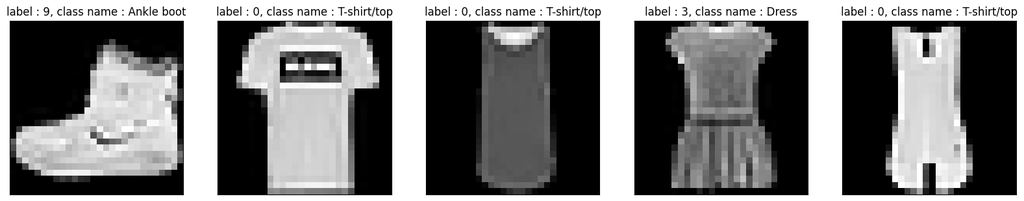

```python
# クラス名の定義
class_names = ['T-shirt/top', 'Trouser', 'Pullover', 'Dress', 'Coat',
               'Sandal', 'Shirt', 'Sneaker', 'Bag', 'Ankle boot']

# データセットの中身を5つ可視化する

fig = plt.figure(figsize=(20,20))
for i in range(5):
    ax = fig.add_subplot(1, 5, i+1, xticks=[], yticks=[])
    ax.imshow(x_train[i].reshape(28,28), cmap='gray')
    ax.set_title( "label : " + str(y_train[i]) + ", class name : " + class_names[y_train[i]] )
plt.show()
```

### データセットの正規化（Min-Max Normalization）

このデータセットの画像は，0から255までの整数から構成されるグレイスケール画像です．

正規化（Min-Max Normalization）は，最大値および最小値が決まっている場合などに，0から1の範囲内にスケーリングする手法です．画像処理などでは訓練コストを下げる目的で利用されることが多いです．

$$ X_{norm} = \frac{X−X_{min}}{X_{max}−X_{min}} $$

※ Min-Max Normalization は外れ値の影響を強く受けます．最大値および最小値が決まっていない場合，外れ値が存在する場合は，別の手法を採用することが多いです．

```python
print("Min-Max Normalization 前")
print("x_train min", x_train.min())
print("x_train max", x_train.max())
print()

x_train = ( x_train - np.min(x_train) ) / ( np.max(x_train) - np.min(x_train) )
x_valid = ( x_valid - np.min(x_valid) ) / ( np.max(x_valid) - np.min(x_valid) )
x_test  = ( x_test  -  np.min(x_test) ) / (  np.max(x_test) -  np.min(x_test) )

print("Min-Max Normalization 後")
print("x_train min", x_train.min())
print("x_train max", x_train.max())
```

```
Min-Max Normalization 前
x_train min 0
x_train max 255

Min-Max Normalization 後
x_train min 0.0
x_train max 1.0
```

## 畳み込みニューラルネットワークモデルの構築

```python
# input層（入力層）：(28 x 28 x 1チャンネル)
inputs_images = tf.keras.layers.Input( shape = (28, 28, 1), name = 'input' )

# 3x3 の 畳み込みカーネル(フィルタ) が32枚
x = tf.keras.layers.Conv2D( filters = 32, strides = (1, 1), kernel_size = (3, 3), activation='relu', name='conv_1')(inputs_images)
# 2x2 の Max Pooling
x = tf.keras.layers.MaxPooling2D( pool_size = (2, 2), strides = (2, 2), name='pool_1')(x)
# 3x3 の 畳み込みカーネル(フィルタ) が64枚
x = tf.keras.layers.Conv2D( filters = 64, strides = (1, 1), kernel_size = (3, 3), activation='relu', name='conv_2')(x)
# 2x2 の Max Pooling
x = tf.keras.layers.MaxPooling2D( pool_size = (2, 2), strides = (2, 2), name='pool_2')(x)


# Flatten層（平坦化層）
# (None, 5, 5, 64) -> (None, 1600)
x = tf.keras.layers.Flatten()(x)

# Dense層（全結合層）
# (None, 1600) -> (None, 512)
x = tf.keras.layers.Dense( units = 512, activation = 'relu' , name='fc_1')(x)
# (None, 512) -> (None, 256)
x = tf.keras.layers.Dense( units = 256, activation = 'relu' , name='fc_2')(x)
# (None, 256) -> (None, 128)
x = tf.keras.layers.Dense( units = 128, activation = 'relu' , name='fc_3')(x)
# (None, 128) -> (None, 10)
outputs = tf.keras.layers.Dense( units = 10, activation = 'softmax' )(x)

# モデルを定義
model = tf.keras.Model( inputs = inputs_images, outputs = outputs, name = 'fashion_mnist_model' )


# モデルのコンパイル（最適化アルゴリズム・損失関数・評価指標などを設定）
# 損失関数は2.6章で学びます．
model.compile(optimizer='adam', #最適化アルゴリズム
              loss='sparse_categorical_crossentropy', # 損失関数
              metrics=['accuracy'] #監視用の指標（モデルの訓練そのものには影響しない）
              )


# モデルの構造をテキストで出力
model.summary()
```

```
Model: "fashion_mnist_model"
```

```
┏━━━━━━━━━━━━━━━━━━━━━━━━━━━━━━━━━┳━━━━━━━━━━━━━━━━━━━━━━━━┳━━━━━━━━━━━━━━━┓
┃ Layer (type)                    ┃ Output Shape           ┃       Param # ┃
┡━━━━━━━━━━━━━━━━━━━━━━━━━━━━━━━━━╇━━━━━━━━━━━━━━━━━━━━━━━━╇━━━━━━━━━━━━━━━┩
│ input (InputLayer)              │ (None, 28, 28, 1)      │             0 │
├─────────────────────────────────┼────────────────────────┼───────────────┤
│ conv_1 (Conv2D)                 │ (None, 26, 26, 32)     │           320 │
├─────────────────────────────────┼────────────────────────┼───────────────┤
│ pool_1 (MaxPooling2D)           │ (None, 13, 13, 32)     │             0 │
├─────────────────────────────────┼────────────────────────┼───────────────┤
│ conv_2 (Conv2D)                 │ (None, 11, 11, 64)     │        18,496 │
├─────────────────────────────────┼────────────────────────┼───────────────┤
│ pool_2 (MaxPooling2D)           │ (None, 5, 5, 64)       │             0 │
├─────────────────────────────────┼────────────────────────┼───────────────┤
│ flatten (Flatten)               │ (None, 1600)           │             0 │
├─────────────────────────────────┼────────────────────────┼───────────────┤
│ fc_1 (Dense)                    │ (None, 512)            │       819,712 │
├─────────────────────────────────┼────────────────────────┼───────────────┤
│ fc_2 (Dense)                    │ (None, 256)            │       131,328 │
├─────────────────────────────────┼────────────────────────┼───────────────┤
│ fc_3 (Dense)                    │ (None, 128)            │        32,896 │
├─────────────────────────────────┼────────────────────────┼───────────────┤
│ dense (Dense)                   │ (None, 10)             │         1,290 │
└─────────────────────────────────┴────────────────────────┴───────────────┘
```

```
 Total params: 1,004,042 (3.83 MB)
```

```
 Trainable params: 1,004,042 (3.83 MB)
```

```
 Non-trainable params: 0 (0.00 B)
```

畳み込み層は `tf.keras.layers.Conv2D`，プーリング層は `tf.keras.layers.MaxPooling2D` で実装しています． 以下の部分が画像の畳み込み処理を行う層になり，画像の特徴を自動的に抽出しています．

```
# input層（入力層）：(28 x 28 x 1チャンネル)
inputs_images = tf.keras.layers.Input( shape = (28, 28, 1), name = 'input' )

# 3x3 の 畳み込みカーネル(フィルタ) が32枚
x = tf.keras.layers.Conv2D( filters = 32, strides = (1, 1), kernel_size = (3, 3), activation='relu', name='conv_1')(inputs_images)
# 2x2 の Max Pooling
x = tf.keras.layers.MaxPooling2D( pool_size = (2, 2), strides = (2, 2), name='pool_1')(x)
# 3x3 の 畳み込みカーネル(フィルタ) が64枚
x = tf.keras.layers.Conv2D( filters = 64, strides = (1, 1), kernel_size = (3, 3), activation='relu', name='conv_2')(x)
# 2x2 の Max Pooling
x = tf.keras.layers.MaxPooling2D( pool_size = (2, 2), strides = (2, 2), name='pool_2')(x)
```

画像データを畳み込み層へ入力する際は，`(height, width, channels)`の形式で与えます．`channels`はカラー画像であればRGBの3チャンネルを使うことが多いですが，今回は白黒のグレースケールなので1チャンネルにしています．

今回は畳み込み層1つ，プーリング層1つ，畳み込み層1つ，プーリング層1つの構成にしています．

各層の出力は全て`(height, width, channels)`になります． 畳み込みカーネルの数だけ，チャンネルが増えます．また，`pool_size = (2, 2)`のプーリング層によって，`(height, width)`は半分になります．

その後，畳み込み処理部分で得られた画像の特徴を元に，`Dense`層でニューラルネットワークと同じように分類をしています．

[output not shown]

`Dense`層へはベクトルで渡す必要があるので，その処理を`Flatten`で行なっています． その後の処理はニューラルネットワークと同じ内容です．

もう一度，モデルの構造を見てみましょう．

```python
model.summary()
```

```
Model: "fashion_mnist_model"
```

```
┏━━━━━━━━━━━━━━━━━━━━━━━━━━━━━━━━━┳━━━━━━━━━━━━━━━━━━━━━━━━┳━━━━━━━━━━━━━━━┓
┃ Layer (type)                    ┃ Output Shape           ┃       Param # ┃
┡━━━━━━━━━━━━━━━━━━━━━━━━━━━━━━━━━╇━━━━━━━━━━━━━━━━━━━━━━━━╇━━━━━━━━━━━━━━━┩
│ input (InputLayer)              │ (None, 28, 28, 1)      │             0 │
├─────────────────────────────────┼────────────────────────┼───────────────┤
│ conv_1 (Conv2D)                 │ (None, 26, 26, 32)     │           320 │
├─────────────────────────────────┼────────────────────────┼───────────────┤
│ pool_1 (MaxPooling2D)           │ (None, 13, 13, 32)     │             0 │
├─────────────────────────────────┼────────────────────────┼───────────────┤
│ conv_2 (Conv2D)                 │ (None, 11, 11, 64)     │        18,496 │
├─────────────────────────────────┼────────────────────────┼───────────────┤
│ pool_2 (MaxPooling2D)           │ (None, 5, 5, 64)       │             0 │
├─────────────────────────────────┼────────────────────────┼───────────────┤
│ flatten (Flatten)               │ (None, 1600)           │             0 │
├─────────────────────────────────┼────────────────────────┼───────────────┤
│ fc_1 (Dense)                    │ (None, 512)            │       819,712 │
├─────────────────────────────────┼────────────────────────┼───────────────┤
│ fc_2 (Dense)                    │ (None, 256)            │       131,328 │
├─────────────────────────────────┼────────────────────────┼───────────────┤
│ fc_3 (Dense)                    │ (None, 128)            │        32,896 │
├─────────────────────────────────┼────────────────────────┼───────────────┤
│ dense (Dense)                   │ (None, 10)             │         1,290 │
└─────────────────────────────────┴────────────────────────┴───────────────┘
```

```
 Total params: 1,004,042 (3.83 MB)
```

```
 Trainable params: 1,004,042 (3.83 MB)
```

```
 Non-trainable params: 0 (0.00 B)
```

`Flatten`層にて，`(5, 5, 64)`の出力は`(5*5*64)`に平坦化されていることがわかります．

コンパイルの内容はニューラルネットワークと同じです．

## データの前処理

データの前処理をしましょう．今回は以下のような処理になります． 異なる点は，入力時に平坦化をする必要は無くなりましたが，チャネル数の部分を追加してあげる必要があります．

```python
print("reshape 前")
print("x_train shape", x_train.shape)

x_train = x_train.reshape((42000, 28, 28, 1))  # 入力配列の構造にチャネル部分を追加
x_valid = x_valid.reshape((18000, 28, 28, 1))  # 入力配列の構造にチャネル部分を追加
x_test = x_test.reshape((10000, 28, 28, 1))  # 入力配列の構造にチャネル部分を追加

print("reshape 後")
print("x_train shape", x_train.shape)
```

```
reshape 前
x_train shape (42000, 28, 28)
reshape 後
x_train shape (42000, 28, 28, 1)
```

## 未訓練モデルの推論結果を可視化する

```
1/1 ━━━━━━━━━━━━━━━━━━━━ 2s 2s/step
```

|  | 0 T-shirt/top | 1 Trouser | 2 Pullover | 3 Dress | 4 Coat | 5 Sandal | 6 Shirt | 7 Sneaker | 8 Bag | 9 Ankle boot |
| --- | --- | --- | --- | --- | --- | --- | --- | --- | --- | --- |
| y_testの推論結果 (i=0) | 0.0984 | 0.1013 | 0.104 | 0.0947 | 0.1009 | 0.0974 | 0.101 | 0.1004 | 0.1024 | 0.0994 |

```
y_test_true (i=0):  9  /  Ankle boot
x_test (i=0):
```

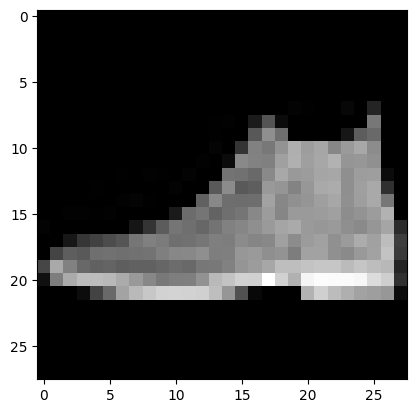

```
-----------------------------------------------------------------------------------------------

1/1 ━━━━━━━━━━━━━━━━━━━━ 0s 85ms/step
```

|  | 0 T-shirt/top | 1 Trouser | 2 Pullover | 3 Dress | 4 Coat | 5 Sandal | 6 Shirt | 7 Sneaker | 8 Bag | 9 Ankle boot |
| --- | --- | --- | --- | --- | --- | --- | --- | --- | --- | --- |
| y_testの推論結果 (i=1) | 0.0979 | 0.1049 | 0.1028 | 0.0958 | 0.1003 | 0.0931 | 0.1026 | 0.0972 | 0.1067 | 0.0986 |

```
y_test_true (i=1):  2  /  Pullover
x_test (i=1):
```

[figure not shown]

```
-----------------------------------------------------------------------------------------------

1/1 ━━━━━━━━━━━━━━━━━━━━ 0s 109ms/step
```

|  | 0 T-shirt/top | 1 Trouser | 2 Pullover | 3 Dress | 4 Coat | 5 Sandal | 6 Shirt | 7 Sneaker | 8 Bag | 9 Ankle boot |
| --- | --- | --- | --- | --- | --- | --- | --- | --- | --- | --- |
| y_testの推論結果 (i=2) | 0.1007 | 0.1026 | 0.1024 | 0.0946 | 0.1037 | 0.0971 | 0.0984 | 0.0998 | 0.1014 | 0.0993 |

```
y_test_true (i=2):  1  /  Trouser
x_test (i=2):
```

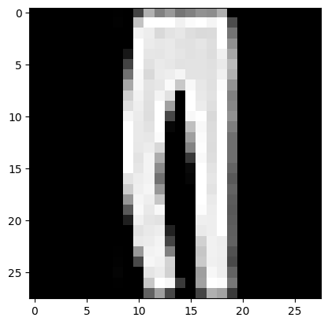

```python
# テストデータの内，先頭3件のデータを可視化
for i in [0,1,2]:
    y_true = y_test[i]
    y_pred = model.predict(x_test[i].reshape(1,28,28,1))[0]

    columns = pd.MultiIndex.from_tuples([(i,n) for i, n in zip(range(10),class_names)])
    display(pd.DataFrame(columns =columns, index = [f'y_testの推論結果 (i={str(i)})'], data=[y_pred.tolist()]))
    print("y_test_true", "(i="+str(i)+"): ", y_true, " / ", class_names[y_true])
    print("x_test", "(i="+str(i)+"): ")
    plt.imshow(x_test[i], cmap='gray')
    plt.show()
    print("-----------------------------------------------------------------------------------------------\n")
```

## モデルの訓練

畳み込み部分が追加されているため，パラメータ数が非常に多くなりました． そのため，訓練には時間がかかります．

```python
# 訓練中のログファイルを作成する準備
callbacks = []
callbacks.append(tf.keras.callbacks.CSVLogger('training_log.csv'))

# .TensorBoardを作成する準備
os.makedirs('/contents/logs/fit/', exist_ok=True)# フォルダ作成
log_dir = "logs/fit/" + datetime.datetime.now().strftime("%Y%m%d-%H%M%S")
tensorboard_callback = tf.keras.callbacks.TensorBoard(log_dir=log_dir, histogram_freq=1)

callbacks.append(tensorboard_callback)

# モデルの訓練（GPUで1分30秒ほど）
history = model.fit(x_train, y_train,
                    batch_size = 128,
                    epochs = 10,
                    verbose = 1,
                    validation_data = (x_valid, y_valid),
                    callbacks = callbacks
                    )


model_save_path = 'trained_model_fashion-mnist.keras'
model.save(model_save_path)
```

```
329/329 ━━━━━━━━━━━━━━━━━━━━ 11s 13ms/step - accuracy: 0.7946 - loss: 0.5629 - val_accuracy: 0.8514 - val_loss: 0.4029
329/329 ━━━━━━━━━━━━━━━━━━━━ 4s 11ms/step - accuracy: 0.8759 - loss: 0.3417 - val_accuracy: 0.8822 - val_loss: 0.3182
329/329 ━━━━━━━━━━━━━━━━━━━━ 4s 13ms/step - accuracy: 0.8936 - loss: 0.2860 - val_accuracy: 0.8947 - val_loss: 0.2876
329/329 ━━━━━━━━━━━━━━━━━━━━ 4s 11ms/step - accuracy: 0.9067 - loss: 0.2486 - val_accuracy: 0.9013 - val_loss: 0.2718
329/329 ━━━━━━━━━━━━━━━━━━━━ 4s 11ms/step - accuracy: 0.9185 - loss: 0.2196 - val_accuracy: 0.9033 - val_loss: 0.2727
329/329 ━━━━━━━━━━━━━━━━━━━━ 4s 13ms/step - accuracy: 0.9270 - loss: 0.1944 - val_accuracy: 0.9046 - val_loss: 0.2775
329/329 ━━━━━━━━━━━━━━━━━━━━ 4s 11ms/step - accuracy: 0.9348 - loss: 0.1725 - val_accuracy: 0.9007 - val_loss: 0.3191
329/329 ━━━━━━━━━━━━━━━━━━━━ 4s 11ms/step - accuracy: 0.9413 - loss: 0.1533 - val_accuracy: 0.8957 - val_loss: 0.3472
329/329 ━━━━━━━━━━━━━━━━━━━━ 4s 13ms/step - accuracy: 0.9485 - loss: 0.1359 - val_accuracy: 0.8945 - val_loss: 0.3646
329/329 ━━━━━━━━━━━━━━━━━━━━ 4s 12ms/step - accuracy: 0.9547 - loss: 0.1218 - val_accuracy: 0.8922 - val_loss: 0.3612
```

## モデルの評価

```python
train_loss, train_acc = model.evaluate(x_train, y_train, verbose=1)
print("loss (train): {:.4}".format(train_loss))
print("accuracy (train): {:.4}".format(train_acc))

print()

valid_loss, valid_acc = model.evaluate(x_valid, y_valid, verbose=1)
print("loss (valid): {:.4}".format(valid_loss))
print("accuracy (valid): {:.4}".format(valid_acc))

print()

test_loss, test_acc = model.evaluate(x_test, y_test, verbose=1)
print("loss (test): {:.4}".format(test_loss))
print("accuracy (test): {:.4}".format(test_acc))
```

```
1313/1313 ━━━━━━━━━━━━━━━━━━━━ 5s 4ms/step - accuracy: 0.9396 - loss: 0.1616
loss (train): 0.1616
accuracy (train): 0.9396

563/563 ━━━━━━━━━━━━━━━━━━━━ 2s 4ms/step - accuracy: 0.8922 - loss: 0.3612
loss (valid): 0.3612
accuracy (valid): 0.8922

313/313 ━━━━━━━━━━━━━━━━━━━━ 2s 6ms/step - accuracy: 0.8867 - loss: 0.4008
loss (test): 0.4008
accuracy (test): 0.8867
```

#### ログの表示

```python
log_df = pd.read_csv('training_log.csv')
display(log_df.head(10))
```

|  | epoch | accuracy | loss | val_accuracy | val_loss |
| --- | --- | --- | --- | --- | --- |
| 0 | 0 | 0.7946 | 0.5629 | 0.8514 | 0.4029 |
| 1 | 1 | 0.8759 | 0.3417 | 0.8822 | 0.3182 |
| 2 | 2 | 0.8936 | 0.2860 | 0.8947 | 0.2876 |
| 3 | 3 | 0.9067 | 0.2486 | 0.9013 | 0.2718 |
| 4 | 4 | 0.9185 | 0.2196 | 0.9033 | 0.2727 |
| 5 | 5 | 0.9270 | 0.1944 | 0.9046 | 0.2775 |
| 6 | 6 | 0.9348 | 0.1725 | 0.9007 | 0.3191 |
| 7 | 7 | 0.9413 | 0.1533 | 0.8957 | 0.3472 |
| 8 | 8 | 0.9485 | 0.1359 | 0.8945 | 0.3646 |
| 9 | 9 | 0.9547 | 0.1218 | 0.8922 | 0.3612 |

#### 損失関数と評価指標の推移

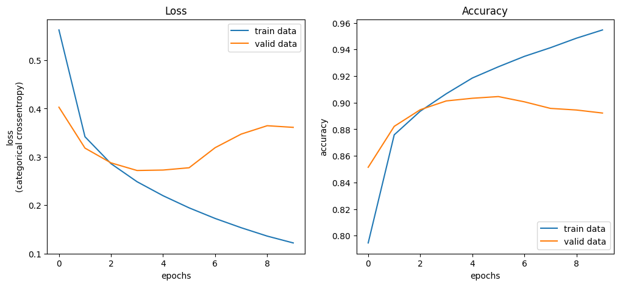

```python
epochs = log_df["epoch"].values
train_acc = log_df["accuracy"].values
train_loss = log_df["loss"].values
valid_acc = log_df["val_accuracy"].values
valid_loss = log_df["val_loss"].values

fig, axes = plt.subplots(1,2, figsize=(12,5))

axes[0].plot(epochs, train_loss, label="train data")
axes[0].plot(epochs, valid_loss, label="valid data")
axes[0].set_xlabel("epochs")
axes[0].set_ylabel("loss\n(categorical crossentropy)")
axes[0].legend(loc="upper right")
axes[0].set_title("Loss")

axes[1].plot(epochs, train_acc, label="train data")
axes[1].plot(epochs, valid_acc, label="valid data")
axes[1].set_xlabel("epochs")
axes[1].set_ylabel("accuracy")
axes[1].legend(loc="lower right")
axes[1].set_title("Accuracy")

plt.show()
```

#### 混同行列の描画

```
313/313 ━━━━━━━━━━━━━━━━━━━━ 1s 2ms/step
```

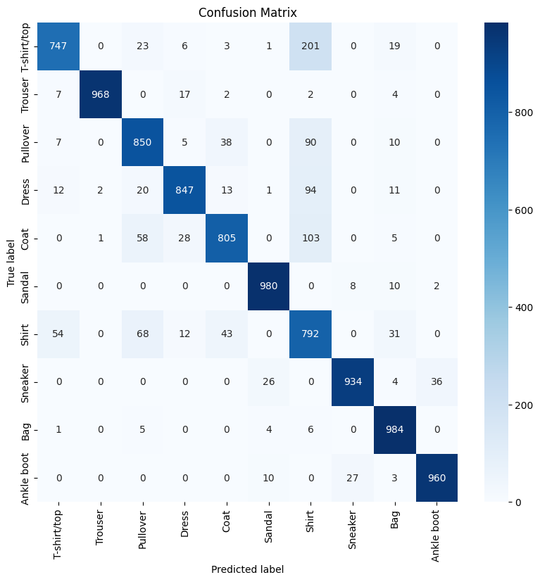

```python
y_pred = np.argmax(model.predict(x_test), axis = -1)
con_matrix = tf.math.confusion_matrix(labels=y_test, predictions=y_pred).numpy()

con_mat_df = pd.DataFrame(con_matrix,
                     index = class_names,
                     columns = class_names
                     )

figure = plt.figure(figsize=(8, 8))
sns.heatmap(con_mat_df, annot=True, cmap=plt.cm.Blues, fmt='g')
plt.tight_layout()
plt.title('Confusion Matrix')
plt.ylabel('True label')
plt.xlabel('Predicted label')
plt.show()
```

#### 一部の推論結果を可視化する

```
1/1 ━━━━━━━━━━━━━━━━━━━━ 0s 48ms/step
```

|  | 0 T-shirt/top | 1 Trouser | 2 Pullover | 3 Dress | 4 Coat | 5 Sandal | 6 Shirt | 7 Sneaker | 8 Bag | 9 Ankle boot |
| --- | --- | --- | --- | --- | --- | --- | --- | --- | --- | --- |
| y_testの推論結果 (i=0) | 3.9335e-10 | 5.0043e-12 | 2.4325e-12 | 2.4785e-11 | 6.6396e-12 | 4.4534e-07 | 3.9844e-10 | 6.3645e-07 | 1.5557e-10 | 1.0 |

```
y_test_true (i=0):  9  /  Ankle boot
x_test (i=0):
```

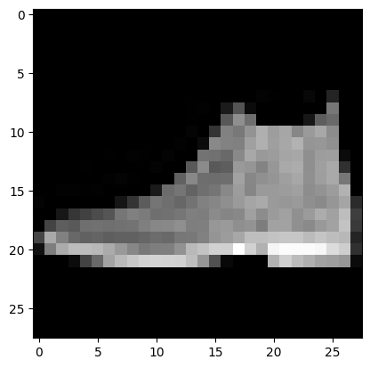

```
-----------------------------------------------------------------------------------------------

1/1 ━━━━━━━━━━━━━━━━━━━━ 0s 49ms/step
```

|  | 0 T-shirt/top | 1 Trouser | 2 Pullover | 3 Dress | 4 Coat | 5 Sandal | 6 Shirt | 7 Sneaker | 8 Bag | 9 Ankle boot |
| --- | --- | --- | --- | --- | --- | --- | --- | --- | --- | --- |
| y_testの推論結果 (i=1) | 1.6471e-09 | 5.1227e-13 | 1.0 | 2.8736e-11 | 1.3527e-06 | 3.1179e-14 | 1.8276e-08 | 2.0798e-15 | 5.0454e-10 | 9.1089e-15 |

```
y_test_true (i=1):  2  /  Pullover
x_test (i=1):
```

[figure not shown]

```
-----------------------------------------------------------------------------------------------

1/1 ━━━━━━━━━━━━━━━━━━━━ 0s 48ms/step
```

|  | 0 T-shirt/top | 1 Trouser | 2 Pullover | 3 Dress | 4 Coat | 5 Sandal | 6 Shirt | 7 Sneaker | 8 Bag | 9 Ankle boot |
| --- | --- | --- | --- | --- | --- | --- | --- | --- | --- | --- |
| y_testの推論結果 (i=2) | 5.1299e-11 | 1.0 | 1.2058e-16 | 1.7893e-15 | 1.9497e-15 | 1.4341e-15 | 5.7845e-16 | 2.3287e-18 | 2.2791e-12 | 1.8419e-16 |

```
y_test_true (i=2):  1  /  Trouser
x_test (i=2):
```

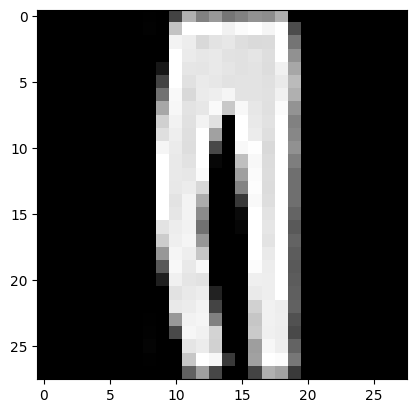

```python
# テストデータの内，先頭3件のデータを可視化
for i in [0,1,2]:
    y_true = y_test[i]
    y_pred = model.predict(x_test[i].reshape(1,28,28,1))[0]

    columns = pd.MultiIndex.from_tuples([(i,n) for i, n in zip(range(10),class_names)])
    display(pd.DataFrame(columns =columns, index = [f'y_testの推論結果 (i={str(i)})'], data=[y_pred.tolist()]))
    print("y_test_true", "(i="+str(i)+"): ", y_true, " / ", class_names[y_true])
    print("x_test", "(i="+str(i)+"): ")
    plt.imshow(x_test[i], cmap='gray')
    plt.show()
    print("-----------------------------------------------------------------------------------------------\n")
```

```python
# 推論結果と正解ラベルが異なる（間違っている）テストデータの index を出力する
y_pred = np.argmax(model.predict(x_test), axis = -1)

np.set_printoptions(threshold=1200) # 配列の表示上限を一時的に変更
display(np.where( y_pred != y_test)[0] )
```

```
313/313 ━━━━━━━━━━━━━━━━━━━━ 1s 2ms/step
```

```
array([  12,   23,   25,   27,   33,   42,   43,   45,   49,   50,   57,
         68,   74,   98,  136,  141,  147,  150,  155,  162,  170,  182,
        192,  217,  223,  229,  244,  248,  258,  271,  309,  312,  316,
        332,  337,  361,  374,  378,  381,  382,  395,  396,  403,  404,
        410,  441,  444,  452,  454,  460,  490,  495,  510,  526,  536,
        558,  569,  578,  594,  607,  623,  624,  628,  634,  635,  651,
        659,  664,  665,  670,  674,  681,  685,  688,  699,  701,  702,
        711,  713,  719,  724,  732,  736,  747,  753,  760,  764,  787,
        800,  851,  870,  881,  890,  905,  930,  935,  937,  938,  956,
        960,  965,  976,  979,  984,  985,  994,  997, 1000, 1016, 1046,
       1051, 1053, 1055, 1056, 1066, 1077, 1087, 1101, 1104, 1111, 1123,
       1131, 1139, 1142, 1158, 1160, 1162, 1165, 1174, 1192, 1194, 1197,
       1205, 1218, 1223, 1224, 1231, 1234, 1254, 1259, 1261, 1270, 1273,
       1280, 1286, 1287, 1293, 1297, 1300, 1305, 1306, 1326, 1329, 1336,
       1350, 1385, 1388, 1408, 1425, 1438, 1449, 1451, 1452, 1455, 1462,
```

[output cut: 88 more lines]

```
1/1 ━━━━━━━━━━━━━━━━━━━━ 0s 48ms/step
1/1 ━━━━━━━━━━━━━━━━━━━━ 0s 47ms/step
1/1 ━━━━━━━━━━━━━━━━━━━━ 0s 49ms/step
1/1 ━━━━━━━━━━━━━━━━━━━━ 0s 44ms/step
1/1 ━━━━━━━━━━━━━━━━━━━━ 0s 44ms/step
1/1 ━━━━━━━━━━━━━━━━━━━━ 0s 49ms/step
1/1 ━━━━━━━━━━━━━━━━━━━━ 0s 47ms/step
1/1 ━━━━━━━━━━━━━━━━━━━━ 0s 44ms/step
1/1 ━━━━━━━━━━━━━━━━━━━━ 0s 45ms/step
1/1 ━━━━━━━━━━━━━━━━━━━━ 0s 44ms/step
1/1 ━━━━━━━━━━━━━━━━━━━━ 0s 46ms/step
1/1 ━━━━━━━━━━━━━━━━━━━━ 0s 46ms/step
1/1 ━━━━━━━━━━━━━━━━━━━━ 0s 45ms/step
1/1 ━━━━━━━━━━━━━━━━━━━━ 0s 46ms/step
1/1 ━━━━━━━━━━━━━━━━━━━━ 0s 45ms/step
1/1 ━━━━━━━━━━━━━━━━━━━━ 0s 43ms/step
1/1 ━━━━━━━━━━━━━━━━━━━━ 0s 50ms/step
1/1 ━━━━━━━━━━━━━━━━━━━━ 0s 49ms/step
1/1 ━━━━━━━━━━━━━━━━━━━━ 0s 46ms/step
1/1 ━━━━━━━━━━━━━━━━━━━━ 0s 44ms/step
```

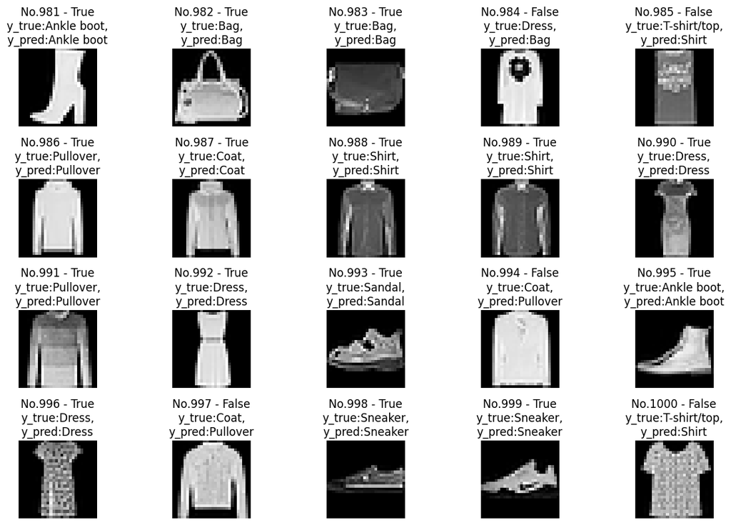

```python
# テストデータの内，start_indexから20件のデータの推論結果を可視化する

fig = plt.figure(figsize=(12, 8))

ROW = 4
COLUMN = 5
start_index = 981

for i in range(start_index, start_index + ROW * COLUMN):
    y_true = y_test[i]
    y_pred = tf.math.argmax(model.predict(x_test[i].reshape(1,28,28,1))[0])

    if y_true == y_pred:
        result = "True"
    else:
        result = "False"

    plt.subplot(ROW, COLUMN, (i-start_index) +1 )
    plt.imshow(x_test[i], cmap='gray')
    plt.title("No.{} - {}\ny_true:{},\ny_pred:{}".format(i, result, class_names[y_true], class_names[y_pred]))
    plt.axis("off")

fig.tight_layout()
fig.show()
```

### tensorboard による可視化

このコードを実行するときは，Colabを開いているブラウザでサードパーティ製のクッキーを許可してください．（もしブロックしていると，403エラーが表示されます．）

```python
%tensorboard --logdir logs/fit
```

## 畳み込みニューラルネットワークは何を見ているか

ここでは，畳み込みニューラルネットワークについての理解を深めるために，訓練済のニューラルネットワークがどのような特徴をとらえているかを，隠れ層の出力（活性化マップ）を可視化することで見てみたいと思います．

まず，訓練済モデルの入力層の次の層から，Flatten層（平坦化）の前の4層の出力を取得し，tf.keras のモデル activation_model を新たに作成します．

```python
# モデルのlayers(層のリスト)より，
# 入力層の次の層から，Flatten層（平坦化）の前の4層の出力を抜粋
layer_outputs = [layer.output for layer in model.layers[1:5]]

display(model.layers[1:5])

# 既存モデルの入力と，上記で取得した各層の出力を出力とするモデルを構築
activation_model = tf.keras.Model(inputs=model.inputs, outputs=layer_outputs)
```

```
[<Conv2D name=conv_1, built=True>,
 <MaxPooling2D name=pool_1, built=True>,
 <Conv2D name=conv_2, built=True>,
 <MaxPooling2D name=pool_2, built=True>]
```

x_test の最初の画像を入力として，推論（順方向処理）を実行します．

x_test[0]とすると次元（階数）が1つ少ない (28, 28, 1) の配列が得られるので，次元拡張によって形状を合わせていることに注意します．

```python
import numpy as np

activations = activation_model.predict(np.expand_dims(x_test[0], 0))
```

```
1/1 ━━━━━━━━━━━━━━━━━━━━ 0s 90ms/step
```

activations は4層分あるので，入力層の次，Conv2D層の出力の形状をみてみましょう．

```python
print(activations[0].shape)
```

```
(1, 26, 26, 32)
```

例として，インデックス3のフィルタの出力する特徴マップを，カラーマップを使って可視化します．

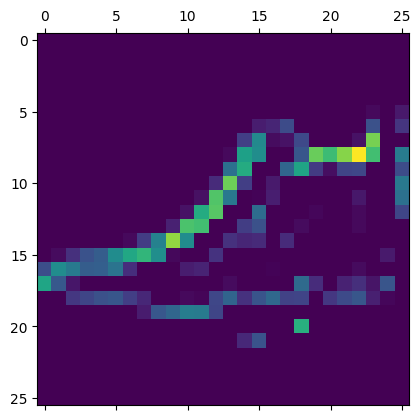

```python
plt.matshow(activations[0][0, :, :, 3], cmap='viridis')
plt.show()
```

各層のパラメータは乱数によって初期化されるため，上記の特徴マップは訓練を実行するごとに異なることに注意してください．

下記のプログラムにより，各層の特徴マップ全体を表示します．

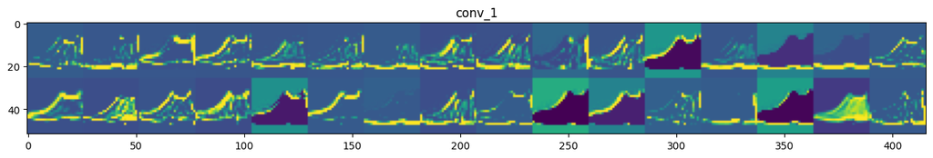

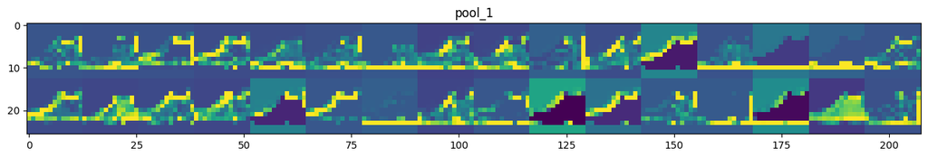

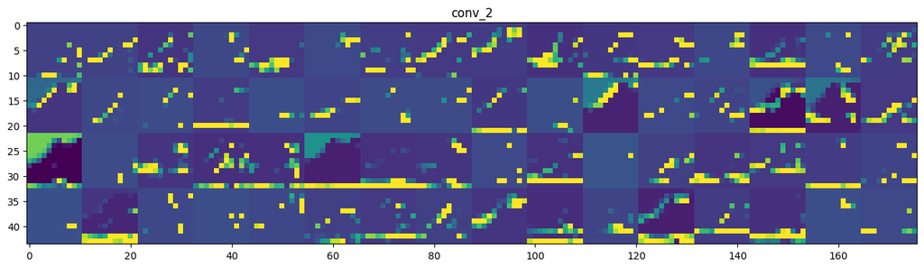

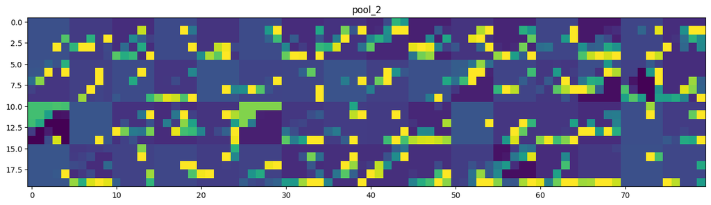

```python
# 各レイヤの名前を抽出
layer_names = []
for layer in model.layers[1:5]:
    layer_names.append(layer.name)

# 1行に表示するイメージ数
images_per_row = 16

# レイヤごとに処理を繰り返す
for layer_name, layer_activation in zip(layer_names, activations):
    # このレイヤの特徴マップの数を調べる
    n_features = layer_activation.shape[-1]

    # 特徴マップのサイズを取得（正方形を仮定している）
    size = layer_activation.shape[1]

    # 画像の行数を計算し画像を並べる0行列を生成
    n_rows = n_features // images_per_row
    display_grid = np.zeros((size * n_rows, images_per_row * size))

    # チャネルごとの特徴マップを取り出し行列に埋め込む
    for row in range(n_rows):
        for col in range(images_per_row):
            channel_image = layer_activation[0, :, :, row * images_per_row + col]
            # 特徴マップを平均0分散1に標準化
            channel_image -= channel_image.mean()
            channel_image /= channel_image.std()
            # 平均128標準偏差64に変換
            channel_image *= 64
            channel_image += 128
            # 0から255の範囲にクリッピングし符号なし8ビット整数化
            channel_image = np.clip(channel_image, 0, 255).astype('uint8')
            # 所定の位置にイメージを埋め込む
            display_grid[row * size : (row + 1) * size,
                         col * size : (col + 1) * size] = channel_image

    # 画像の表示
    scale = 1. / size
    plt.figure(figsize=(scale * display_grid.shape[1],
                        scale * display_grid.shape[0]))
    plt.title(layer_name)
    plt.grid(False)
    plt.imshow(display_grid, aspect='auto', cmap='viridis')

plt.show()
```